# Neural Network Project

## Now building a Deep neural net with batch normalization, weight initializers and using RELU as an activation function.

```python
model1 = Sequential()
model1.add(Dense(100, input_shape = (1024, ), activation ='relu', kernel_initializer='he_normal'))
model1.add(BatchNormalization())
model1.add(Dense(300,activation = 'relu', kernel_initializer='he_normal'))
model1.add(BatchNormalization())
model1.add(Dense(500,activation = 'relu', kernel_initializer='he_normal'))
model1.add(BatchNormalization())
model1.add(Dense(300,activation = 'relu', kernel_initializer='he_normal'))
model1.add(BatchNormalization())
model1.add(Dense(10, activation = 'sigmoid', kernel_initializer='he_normal'))

model1.compile(optimizer = 'adam', loss = 'categorical_crossentropy', metrics= ['accuracy'])
```

```python
model1.fit(train_X,train_Y, epochs = 100, batch_size = 100, verbose =1)
```

```
Train on 37800 samples
```

```
<tensorflow.python.keras.callbacks.History at 0x2687e5135c0>
```

```python
model1.evaluate(Val_X, Val_Y)
```

```
[1.2637894013524056, 0.7866667]
```

Accuracy on the validation set is low that is 78.67% with loss of 1.263.

```python
model1.evaluate(test_X, Y_test)
```

```
[1.243792657978005, 0.7838889]
```

## Now building a model with LeakyRelu as activation function and also including dropout in the model.

```python
model2 = Sequential()
model2.add(Dense(50, input_shape = (1024, ), kernel_initializer='he_normal'))
model2.add(BatchNormalization())
model2.add(LeakyReLU(alpha=0.01))
model2.add(Dropout(0.2))
model2.add(Dense(50, kernel_initializer='he_normal'))
model2.add(BatchNormalization())
model2.add(LeakyReLU(alpha=0.01))
model2.add(Dropout(0.2))
model2.add(Dense(100, kernel_initializer='he_normal'))
model2.add(BatchNormalization())
model2.add(LeakyReLU(alpha=0.01))
model2.add(Dropout(0.2))
model2.add(Dense(100, kernel_initializer='he_normal'))
model2.add(BatchNormalization())
model2.add(LeakyReLU(alpha=0.01))
model2.add(Dropout(0.2))
model2.add(Dense(10,activation = 'sigmoid'))

adam = optimizers.Adam()
model2.compile(optimizer = adam, loss = 'binary_crossentropy', metrics = ['accuracy'])
```

```python
model2.fit(train_X, train_Y, epochs = 200, batch_size = 100, verbose = 1)
```

```
Train on 37800 samples
```

```
<tensorflow.python.keras.callbacks.History at 0x2680430b748>
```

```python
model2.evaluate(Val_X,Val_Y)
```

```
[0.09986771628970191, 0.9658093]
```

```python
model2.evaluate(test_X,Y_test)
```

```
[0.09955851468775008, 0.9656943]
```

```python
pred_val = model2.predict_classes(Val_X)
```

```python
pred_val
```

```
array([7, 5, 5, ..., 7, 2, 4], dtype=int64)
```

```python
pred_test = model2.predict_classes(test_X)
```

```python
for i in range(0,30):
    print (pred_test[i],end = ' ')
```

```
0 7 2 9 0 9 1 5 1 4 8 2 1 4 3 5 8 6 5 5 0 6 5 8 3 2 0 4 9 5
```

```python
Y_actual = np.argmax(Y_test,axis=1)
```

```python
for i in range(0,30):
    print (Y_actual[i],end = ' ')
```

```
1 7 2 9 0 9 1 8 4 4 8 9 1 4 3 5 8 6 5 5 0 6 5 8 3 2 0 1 9 5
```

### The above model shows highest accuracy for both validation set as well as test data. Thus, the model seems good enough to predict values from the SVHN dataset.

Now creating a confusion matrix of the above model2 and also will analyse the Precision and F1 Score analysis

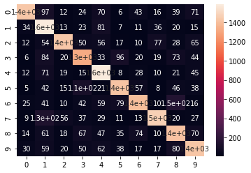

```python
confMatrix = metrics.confusion_matrix(Y_actual, pred_test, labels=[0,1,2,3,4,5,6,7,8,9])
confM_data = pd.DataFrame(confMatrix, index = [i for i in [0,1,2,3,4,5,6,7,8,9]],
                          columns = [i for i in [0,1,2,3,4,5,6,7,8,9]])
sb.heatmap(confM_data, annot=True)
```

```python
metrics.confusion_matrix(Y_actual, pred_test,labels=[0,1,2,3,4,5,6,7,8,9])
```

```
array([[1436,   97,   12,   24,   70,    6,   43,   16,   39,   71],
       [  34, 1588,   13,   23,   81,    7,   11,   36,   20,   15],
       [  12,   54, 1434,   50,   56,   17,   10,   77,   28,   65],
       [   6,   84,   20, 1324,   33,   96,   20,   19,   73,   44],
       [  12,   71,   19,   15, 1583,    8,   28,   10,   21,   45],
       [   5,   42,   15,  109,   21, 1427,   57,    8,   46,   38],
       [  25,   41,   10,   42,   59,   79, 1400,   10,  150,   16],
       [   9,  131,   56,   37,   29,   11,   13, 1475,   20,   27],
       [  14,   61,   18,   67,   47,   35,   74,   10, 1416,   70],
       [  30,   59,   20,   50,   62,   38,   17,   17,   80, 1431]],
      dtype=int64)
```

```python
class_rep = metrics.classification_report(Y_actual,pred_test,labels=[0,1,2,3,4,5,6,7,8,9],digits=3,output_dict=True)
```

```python
class_report = pd.DataFrame(data=class_rep)
```

```python
class_report.T
```

|  | precision | recall | f1-score | support |
| --- | --- | --- | --- | --- |
| 0 | 0.907138 | 0.791621 | 0.845452 | 1814.000000 |
| 1 | 0.712747 | 0.868709 | 0.783037 | 1828.000000 |
| 2 | 0.886827 | 0.795341 | 0.838596 | 1803.000000 |
| 3 | 0.760482 | 0.770215 | 0.765318 | 1719.000000 |
| 4 | 0.775600 | 0.873620 | 0.821697 | 1812.000000 |
| 5 | 0.827726 | 0.807127 | 0.817297 | 1768.000000 |
| 6 | 0.836820 | 0.764192 | 0.798859 | 1832.000000 |
| 7 | 0.879023 | 0.815819 | 0.846242 | 1808.000000 |
| 8 | 0.748019 | 0.781457 | 0.764372 | 1812.000000 |
| 9 | 0.785401 | 0.793237 | 0.789300 | 1804.000000 |
| accuracy | 0.806333 | 0.806333 | 0.806333 | 0.806333 |
| macro avg | 0.811978 | 0.806134 | 0.807017 | 18000.000000 |
| weighted avg | 0.812115 | 0.806333 | 0.807165 | 18000.000000 |